# Data Processing and Analysis in Python

## ASSIGNMENT 4 - Pandas

Name: Krupa Nilesh Shah  
Course: BUDT704  
Section: 0501  
Date: 10-20-23

# Inc. 5000 Analysis

The Inc. 5000 list is a prestigious annual ranking that recognizes the fastest-growing private companies in the United States. To be considered for this list, companies must meet certain criteria. They need to demonstrate substantial revenue growth from 2014 to 2017, starting with a minimum revenue of 100,000 in 2014 and reaching at least 2 million in 2017. These companies must also be founded and generating revenue by March 31, 2014, and they must be U.S.-based, privately held, for-profit, and independent entities, not subsidiaries or divisions of other companies, as of December 31, 2017. In cases where companies have equal growth rates, those with higher revenues are ranked higher on the list. Please let me know if you need further clarification or more specific details.  
Here as a Analyst we will first start implementing Exploratory Data Analysis on the dataset before looking for insights from the dataset.

```python
# Importing the libraries to be used for the Dataset
import numpy as np
import pandas as pd
import seaborn as sns
import matplotlib.pyplot as plt
```

```python
#Calling the dataset along with specifying the index
path = ''
inc_5000 = pd.read_excel(path + 'HW4_inc5000-2018.xlsx', index_col='RANK')
inc_5000.head(25)
```

| RANK | URL | CITY | GROWTH | EMPLOYEES | COMPANY NAME | WEBSITE | CITY.1 | STATE | REVENUW | ZIP CODE | FOUNDED | INDUSTRY | CITY, STATE | Unnamed: 14 | Unnamed: 15 |
| --- | --- | --- | --- | --- | --- | --- | --- | --- | --- | --- | --- | --- | --- | --- | --- |
| 1 | https://www.inc.com/profile/swanleap | Madison | 75660.8425 | 49 | SwanLeap | http://swanleap.com | Wisconsin | WI | 98965631 | 53719 | 2013.0 | Logistics & Transportation | Madison, WI | Makes software for the logistics industry that... | During stints as a freight broker and shipping... |
| 2 | https://www.inc.com/profile/popsockets | Boulder | 71423.7620 | 118 | PopSockets | http://popsockets.com | Colorado | CO | 168837562 | 80301 | 2010.0 | Consumer Products & Services | Boulder, CO | Makes self-adhesive, collapsible, expandable c... | Frustrated with his iPhone headphones getting ... |
| 3 | https://www.inc.com/profile/home-chef | Chicago | 60165.5058 | 865 | Home Chef | homechef.com | Illinois | IL | 255047839 | 60611 | 2013.0 | Food & Beverage | Chicago-Naperville-Elgin, IL-IN-WI | NaN | NaN |
| 4 | https://www.inc.com/profile/velocity-global | Denver | 39816.5093 | 55 | Velocity Global | http://velocityglobal.com | Colorado | CO | 49175942 | 80205 | 2013.0 | Business Products & Services | Denver-Aurora-Lakewood, CO | NaN | NaN |
| 5 | https://www.inc.com/profile/depcom-power | Scottsdale | 38962.9022 | 104 | DEPCOM Power | depcompower.com | Arizona | AZ | 219574136 | 85258 | 2013.0 | Energy | Phoenix-Mesa-Scottsdale, AZ | NaN | NaN |
| 6 | https://www.inc.com/profile/aeronux-airways | Marietta | 20005.2390 | 17 | Aeronux Airways | aeronux.com | Georgia | GA | 21874500 | 30066 | 2011.0 | Logistics & Transportation | Atlanta-Sandy Springs-Roswell, GA | NaN | NaN |
| 7 | https://www.inc.com/profile/diamond-assets | Milton | 19717.5129 | 41 | Diamond Assets | diamond-assets.com | Wisconsin | WI | 43084462 | 53563 | 2014.0 | Computer Hardware | Janesville, WI | NaN | NaN |
| 8 | https://www.inc.com/profile/gforce-life-sciences | Chicago | 16426.6575 | 13 | GForce Life Sciences | http://gforcestaff.com | Illinois | IL | 16893384 | 60606 | 2013.0 | Human Resources | Chicago-Naperville-Elgin, IL-IN-WI | NaN | NaN |
| 8 | https://www.inc.com/profile/flexport | San Francisco | 15911.2237 | 532 | Flexport | http://flexport.com | California | CA | 224745864 | 94102 | 2013.0 | Logistics & Transportation | San Francisco-Oakland-Hayward, CA | NaN | NaN |
| 9 | https://www.inc.com/profile/scientistcom | Solana Beach | 15267.7557 | 49 | Scientist.com | http://scientist.com | California | CA | 50268390 | 92075 | 2007.0 | Health | San Diego-Carlsbad, CA | NaN | NaN |
| 10 | https://www.inc.com/profile/the-garrett-companies | Greenwood | 14821.8995 | 40 | The Garrett Companies | http://thegarrettco.com | Indiana | IN | 82070447 | 46143 | 2014.0 | Real Estate | Indianapolis-Carmel-Anderson, IN | NaN | NaN |
| 11 | https://www.inc.com/profile/dgc-international | Vienna | 14475.5148 | 55 | DGC International | dgci.com | Virginia | VA | 179707790 | 22182 | 2010.0 | Government Services | Washington-Arlington-Alexandria, DC-VA-MD-WV | NaN | NaN |
| 12 | https://www.inc.com/profile/exabeam | San Mateo | 14032.4773 | 153 | Exabeam | exabeam.com | California | CA | 18781497 | 94403 | 2013.0 | Security | San Francisco-Oakland-Hayward, CA | NaN | NaN |
| 13 | https://www.inc.com/profile/podium | Lehi | 13645.2287 | 254 | Podium | podium.com | Utah | UT | 30248850 | 84043 | 2013.0 | Business Products & Services | Provo-Orem, UT | NaN | NaN |
| 14 | https://www.inc.com/profile/inova-us | Key Biscayne | 13135.1845 | 25 | Inova US | inovaus.com | Florida | FL | 39445482 | 33149 | 2008.0 | Advertising & Marketing | Miami-Fort Lauderdale-West Palm Beach, FL | NaN | NaN |
| 15 | https://www.inc.com/profile/adrizer | Sarasota | 12500.7218 | 24 | AdRizer | adrizer.com | Florida | FL | 16723552 | 34236 | 2013.0 | Software | Sarasota-Bradenton-Venice, FL | NaN | NaN |
| 16 | https://www.inc.com/profile/welfont | Tampa | 11359.3104 | 55 | Welfont | welfont.com | Florida | FL | 14055761 | 33602 | 2014.0 | Real Estate | Tampa-St. Petersburg-Clearwater, FL | NaN | NaN |
| 17 | https://www.inc.com/profile/thinx | New York City | 10924.1379 | 44 | THINX | shethinx.com | New York | NY | 39556922 | 10001 | 2014.0 | Retail | New York-Newark-Jersey City, NY-NJ-PA | NaN | NaN |
| 18 | https://www.inc.com/profile/draken-international | Lakeland | 10562.3592 | 200 | Draken International | drakenintl.com | Florida | FL | 30403184 | 33811 | 2011.0 | Government Services | Lakeland, FL | NaN | NaN |
| 19 | https://www.inc.com/profile/calmcom | San Francisco | 10548.7682 | 25 | Calm.com | calm.com | California | CA | 22347505 | 94105 | 2012.0 | Consumer Products & Services | San Francisco-Oakland-Hayward, CA | NaN | NaN |
| 20 | https://www.inc.com/profile/curate-partners | Stoneham | 10056.5729 | 13 | Curate Partners | curatepartners.com | Massachusetts | MA | 12328556 | 2180 | 2014.0 | Human Resources | Boston-Cambridge-Newton, MA-NH | NaN | NaN |
| 21 | https://www.inc.com/profile/figs | Los Angeles | 9947.5655 | 45 | FIGS | wearfigs.com | California | CA | 23115831 | 90064 | 2013.0 | Retail | Los Angeles-Long Beach-Anaheim, CA | NaN | NaN |
| 22 | https://www.inc.com/profile/techanax | Woodbridge | 9508.0119 | 20 | TechAnax | techanax.com | Virginia | VA | 24498797 | 22193 | 2012.0 | Government Services | Washington-Arlington-Alexandria, DC-VA-MD-WV | NaN | NaN |
| 24 | https://www.inc.com/profile/snacknation | Culver City | 9199.5777 | 158 | SnackNation | snacknation.com | California | CA | 16890172 | 90232 | 2014.0 | Food & Beverage | Los Angeles-Long Beach-Anaheim, CA | NaN | NaN |
| 25 | https://www.inc.com/profile/brooklinen | Brooklyn | 9154.1993 | 22 | Brooklinen | brooklinen.com | New York | NY | 47864847 | 11201 | 2014.0 | Retail | New York-Newark-Jersey City, NY-NJ-PA | NaN | NaN |

```python
#To get the count of the companies to verify the number of companies in the dataset
inc_5000['COMPANY NAME'].count()
```

```
5000
```

## Cleaning the Dataset

#### Now that we have imported the dataset it is time to start workinng on cleaning up the dataset a bit to get rid of any anomalies and to get a well functioning dataset.

```python
#Removing the http:// from the website column to get a better constructed column
inc_5000['WEBSITE'] = inc_5000['WEBSITE'].str.replace('http://', '')
```

```python
#Renaming few columns to get better understand of the contents in that column
inc_5000.rename(columns={'CITY.1': 'STATE','STATE': 'STATE CODE','REVENUW': 'REVENUE'}, inplace=True)
#Checkingg the changes made
inc_5000.head()
```

| RANK | URL | CITY | GROWTH | EMPLOYEES | COMPANY NAME | WEBSITE | STATE | STATE CODE | REVENUE | ZIP CODE | FOUNDED | INDUSTRY | CITY, STATE | Unnamed: 14 | Unnamed: 15 |
| --- | --- | --- | --- | --- | --- | --- | --- | --- | --- | --- | --- | --- | --- | --- | --- |
| 1 | https://www.inc.com/profile/swanleap | Madison | 75660.8425 | 49 | SwanLeap | swanleap.com | Wisconsin | WI | 98965631 | 53719 | 2013.0 | Logistics & Transportation | Madison, WI | Makes software for the logistics industry that... | During stints as a freight broker and shipping... |
| 2 | https://www.inc.com/profile/popsockets | Boulder | 71423.7620 | 118 | PopSockets | popsockets.com | Colorado | CO | 168837562 | 80301 | 2010.0 | Consumer Products & Services | Boulder, CO | Makes self-adhesive, collapsible, expandable c... | Frustrated with his iPhone headphones getting ... |
| 3 | https://www.inc.com/profile/home-chef | Chicago | 60165.5058 | 865 | Home Chef | homechef.com | Illinois | IL | 255047839 | 60611 | 2013.0 | Food & Beverage | Chicago-Naperville-Elgin, IL-IN-WI | NaN | NaN |
| 4 | https://www.inc.com/profile/velocity-global | Denver | 39816.5093 | 55 | Velocity Global | velocityglobal.com | Colorado | CO | 49175942 | 80205 | 2013.0 | Business Products & Services | Denver-Aurora-Lakewood, CO | NaN | NaN |
| 5 | https://www.inc.com/profile/depcom-power | Scottsdale | 38962.9022 | 104 | DEPCOM Power | depcompower.com | Arizona | AZ | 219574136 | 85258 | 2013.0 | Energy | Phoenix-Mesa-Scottsdale, AZ | NaN | NaN |

After working on all the visible faults next step will be to check the null values as it will help us further understand what are the different columns with what number of null values.

```python
inc_5000.isnull().sum(axis=0)
```

```
URL                0
CITY               1
GROWTH             0
EMPLOYEES          0
COMPANY NAME       0
WEBSITE            0
STATE              1
STATE CODE         1
REVENUE            0
ZIP CODE           0
FOUNDED            1
INDUSTRY           0
CITY, STATE       24
Unnamed: 14     4998
Unnamed: 15     4998
dtype: int64
```

```python
# Now that we know the values of null values, we will get rid of the last two columns to get a properly structured dataset.
inc_5000_1 = inc_5000.dropna(thresh=3, axis=1)
#Checkingg the changes made
inc_5000_1.head()
```

| RANK | URL | CITY | GROWTH | EMPLOYEES | COMPANY NAME | WEBSITE | STATE | STATE CODE | REVENUE | ZIP CODE | FOUNDED | INDUSTRY | CITY, STATE |
| --- | --- | --- | --- | --- | --- | --- | --- | --- | --- | --- | --- | --- | --- |
| 1 | https://www.inc.com/profile/swanleap | Madison | 75660.8425 | 49 | SwanLeap | swanleap.com | Wisconsin | WI | 98965631 | 53719 | 2013.0 | Logistics & Transportation | Madison, WI |
| 2 | https://www.inc.com/profile/popsockets | Boulder | 71423.7620 | 118 | PopSockets | popsockets.com | Colorado | CO | 168837562 | 80301 | 2010.0 | Consumer Products & Services | Boulder, CO |
| 3 | https://www.inc.com/profile/home-chef | Chicago | 60165.5058 | 865 | Home Chef | homechef.com | Illinois | IL | 255047839 | 60611 | 2013.0 | Food & Beverage | Chicago-Naperville-Elgin, IL-IN-WI |
| 4 | https://www.inc.com/profile/velocity-global | Denver | 39816.5093 | 55 | Velocity Global | velocityglobal.com | Colorado | CO | 49175942 | 80205 | 2013.0 | Business Products & Services | Denver-Aurora-Lakewood, CO |
| 5 | https://www.inc.com/profile/depcom-power | Scottsdale | 38962.9022 | 104 | DEPCOM Power | depcompower.com | Arizona | AZ | 219574136 | 85258 | 2013.0 | Energy | Phoenix-Mesa-Scottsdale, AZ |

## Merging the Dataset

#### Now that we have cleaned the dataset its time to merge the dataset with the region dataset to get the required columns from it.

- For merging both the dataset firstly we will look for the common column which is present in both the dataset to join them.
- After getting the base column we will perform a left merge so that to get all the values from the original inc 5000 dataset
- The next thing will be to get the columns that we want from the region dataset.

```python
#Calling the dataset along with specifying the index
path = ''
region = pd.read_csv(path + 'HW4_states_by_region.csv', index_col='State')
region.head(5)
```

| State | State Code | Region | Division |
| --- | --- | --- | --- |
| Alaska | AK | West | Pacific |
| Alabama | AL | South | East South Central |
| Arkansas | AR | South | West South Central |
| Arizona | AZ | West | Mountain |
| California | CA | West | Pacific |

```python
#Renaming few columns to get better understand of the contents in that column
region.rename(columns={'State Code': 'STATE CODE', 'Region' : 'REGION'}, inplace=True)
```

```python
#Merging both the datasets to get the updated dataset
inc_5000_updated = pd.merge(inc_5000_1, region[['STATE CODE','REGION']], how = 'left', on='STATE CODE')
inc_5000_updated.head()
```

|  | URL | CITY | GROWTH | EMPLOYEES | COMPANY NAME | WEBSITE | STATE | STATE CODE | REVENUE | ZIP CODE | FOUNDED | INDUSTRY | CITY, STATE | REGION |
| --- | --- | --- | --- | --- | --- | --- | --- | --- | --- | --- | --- | --- | --- | --- |
| 0 | https://www.inc.com/profile/swanleap | Madison | 75660.8425 | 49 | SwanLeap | swanleap.com | Wisconsin | WI | 98965631 | 53719 | 2013.0 | Logistics & Transportation | Madison, WI | Midwest |
| 1 | https://www.inc.com/profile/popsockets | Boulder | 71423.7620 | 118 | PopSockets | popsockets.com | Colorado | CO | 168837562 | 80301 | 2010.0 | Consumer Products & Services | Boulder, CO | West |
| 2 | https://www.inc.com/profile/home-chef | Chicago | 60165.5058 | 865 | Home Chef | homechef.com | Illinois | IL | 255047839 | 60611 | 2013.0 | Food & Beverage | Chicago-Naperville-Elgin, IL-IN-WI | Midwest |
| 3 | https://www.inc.com/profile/velocity-global | Denver | 39816.5093 | 55 | Velocity Global | velocityglobal.com | Colorado | CO | 49175942 | 80205 | 2013.0 | Business Products & Services | Denver-Aurora-Lakewood, CO | West |
| 4 | https://www.inc.com/profile/depcom-power | Scottsdale | 38962.9022 | 104 | DEPCOM Power | depcompower.com | Arizona | AZ | 219574136 | 85258 | 2013.0 | Energy | Phoenix-Mesa-Scottsdale, AZ | West |

# Statistical insights of the Data

#### Now that we are looking for statistical insights from the dataset we will start by finding the revenue insights :

- Minimum revenue of a company
- Maximum revenue of a company
- Mean revenue of a company
- Median revenue of a company
- Standard Deviation

```python
#Statistical Analusis of the updated dataset
inc_5000_updated1 = inc_5000_updated.describe()
inc_5000_updated1
```

|  | GROWTH | EMPLOYEES | REVENUE | ZIP CODE | FOUNDED |
| --- | --- | --- | --- | --- | --- |
| count | 5000.000000 | 5000.000000 | 5.000000e+03 | 5000.000000 | 4999.000000 |
| mean | 538.259510 | 229.354600 | 4.122126e+07 | 51317.199000 | 2005.057612 |
| std | 2180.464112 | 2670.284102 | 2.829903e+08 | 30895.477418 | 30.101779 |
| min | 57.235800 | 0.000000 | 1.952209e+06 | 907.000000 | 0.000000 |
| 25% | 97.754925 | 22.000000 | 4.480684e+06 | 22314.000000 | 2003.000000 |
| 50% | 171.758700 | 46.000000 | 9.575010e+06 | 47404.000000 | 2008.000000 |
| 75% | 387.126325 | 115.250000 | 2.497803e+07 | 80302.000000 | 2011.000000 |
| max | 75660.842500 | 150000.000000 | 1.643321e+10 | 99515.000000 | 2014.000000 |

To get these statistical values in concise form we will get the values of various functions for the revenue generated.

```python
print(f'Minimum Revenue of a company is ${inc_5000_updated["REVENUE"].min()}')
print(f'Maximum Revenue of a company is ${inc_5000_updated["REVENUE"].max()}')
print(f'Median Revenue of a company is ${inc_5000_updated["REVENUE"].median():.2f}')
print(f'Mean Revenue of a company is ${inc_5000_updated["REVENUE"].mean():.2f}')
print(f'Standard Deviation of the Revenue of a company is {inc_5000_updated["REVENUE"].std():.2f}')
```

```
Minimum Revenue of a company is $1952209
Maximum Revenue of a company is $16433210000
Median Revenue of a company is $9575009.50
Mean Revenue of a company is $41221263.20
Standard Deviation of the Revenue of a company is 282990264.70
```

```python
#here we will look for companies who have revenue above 50 million and have been started before 2015
companies = len(inc_5000_updated[inc_5000_updated['FOUNDED'] > 1800])
revenue_above_50mil = len(inc_5000_updated[inc_5000_updated['REVENUE'] >= 50000000])
print(f'Percentage of Companies founded before 2015 with average revenue greater than 50 million is {((revenue_above_50mil/companies)*100):.2f}%')
```

```
Percentage of Companies founded before 2015 with average revenue greater than 50 million is 13.63%
```

#### OBSERVATIONS

- Here we see that the companies that have revenue above 50 million are 13.62 percent of all the companies in INC 5000.
- These are all the companies which are on top of their games and are afloat with great margins.

# Functiontional Dataset

- Here we see that we can further get intricate insights from our dataset if we create a function which depicts a particular value of each category.
- This function is very useful because it helps us get the number of rows of values we want for the analysis in descending order.
- This function can be used on any category of the dataset to get inisghts eg. state, city, etc.

```python
#Here we will try working on a function which should return a data frame containing the top n rows of companies, based on revenues for a specific value in the category, only if both category andvalue are provided.
def filter_and_display_top_companies(data_frame, category=None, value=None, n=10):
    if category is None and value is None:
        # If category and value are not provided, display top n companies overall
        top_n_companies = data_frame.nlargest(n, 'REVENUE')
    elif category is not None and value is not None:
        # If both category and value are provided, filter companies based on the specified category and value
        filtered_data = data_frame[data_frame[category] == value]
        top_n_companies = filtered_data.nlargest(n, 'REVENUE')
    return top_n_companies
```

```python
#To get overall top 15 companies
filter_and_display_top_companies(inc_5000_updated, None, None, 15)
```

|  | URL | CITY | GROWTH | EMPLOYEES | COMPANY NAME | WEBSITE | STATE | STATE CODE | REVENUE | ZIP CODE | FOUNDED | INDUSTRY | CITY, STATE | REGION |
| --- | --- | --- | --- | --- | --- | --- | --- | --- | --- | --- | --- | --- | --- | --- |
| 1287 | https://www.inc.com/profile/prime-therapeutics | Eagan | 372.1123 | 4329 | Prime Therapeutics | primetherapeutics.com | Minnesota | MN | 16433210000 | 55121 | 1998.0 | Health | Minneapolis-St. Paul-Bloomington, MN-WI | Midwest |
| 1317 | https://www.inc.com/profile/allied-universal | Santa Ana | 363.0638 | 150000 | Allied Universal | aus.com | California | CA | 5301534000 | 92705 | 1965.0 | Security | Los Angeles-Long Beach-Anaheim, CA | West |
| 4225 | https://www.inc.com/profile/carahsoft-technology | Reston | 80.4559 | 900 | Carahsoft Technology | carahsoft.com | Virginia | VA | 4107537719 | 20190 | 2004.0 | Government Services | Washington-Arlington-Alexandria, DC-VA-MD-WV | South |
| 3438 | https://www.inc.com/profile/endeavor | Beverly Hills | 110.9724 | 6200 | Endeavor | endeavorco.com | New York | NY | 3541178000 | 90210 | 1995.0 | Media | Los Angeles-Long Beach-Anaheim, CA | Northeast |
| 4340 | https://www.inc.com/profile/drivetime | Tempe | 76.6689 | 6111 | DriveTime | drivetime.com | Arizona | AZ | 3267077000 | 85281 | 2002.0 | Consumer Products & Services | Phoenix-Mesa-Scottsdale, AZ | West |
| 4203 | https://www.inc.com/profile/armada | Pittsburgh | 81.1360 | 468 | ARMADA | armada.net | Pennsylvania | PA | 2950772000 | 15238 | 1890.0 | Logistics & Transportation | Pittsburgh, PA | Northeast |
| 3545 | https://www.inc.com/profile/srs-distribution | McKinney | 106.2021 | 3132 | SRS Distribution | srsdistribution.com | Texas | TX | 2183778171 | 75070 | 2008.0 | Consumer Products & Services | Dallas-Fort Worth-Arlington, TX | South |
| 2063 | https://www.inc.com/profile/pinnacle-group | Dallas | 216.2477 | 1563 | Pinnacle Group | pinnacle1.com | Texas | TX | 2110176184 | 75240 | 1996.0 | Human Resources | Dallas-Fort Worth-Arlington, TX | South |
| 4972 | https://www.inc.com/profile/insight-global | Atlanta | 58.1746 | 2570 | Insight Global | insightglobal.com | Georgia | GA | 1928758851 | 30319 | 2001.0 | Business Products & Services | Atlanta-Sandy Springs-Roswell, GA | South |
| 3009 | https://www.inc.com/profile/transportation-ins... | Hickory | 134.1974 | 510 | Transportation Insight | transportationinsight.com | North Carolina | NC | 1892660132 | 28602 | 1999.0 | Logistics & Transportation | Hickory-Lenoir-Morganton, NC | South |
| 1387 | https://www.inc.com/profile/victra | Raleigh | 341.3350 | 6000 | VICTRA | victra.com | North Carolina | NC | 1460373019 | 27615 | 1996.0 | Retail | Raleigh-Cary, NC | South |
| 3495 | https://www.inc.com/profile/strike | The Woodlands | 107.8916 | 5939 | Strike | strikeusa.com | Texas | TX | 1401259860 | 77380 | 2003.0 | Energy | Houston-The Woodlands-Sugar Land, TX | South |
| 4550 | https://www.inc.com/profile/avella-specialty-p... | Phoenix | 71.2137 | 706 | Avella Specialty Pharmacy | avella.com | Arizona | AZ | 1351981297 | 85085 | 1996.0 | Health | Phoenix-Mesa-Scottsdale, AZ | West |
| 2109 | https://www.inc.com/profile/jeunesse-global | Lake Mary | 210.2303 | 825 | Jeunesse Global | jeunesseglobal.com | Florida | FL | 1300731294 | 32746 | 2009.0 | Consumer Products & Services | Orlando-Kissimmee-Sanford, FL | South |
| 4986 | https://www.inc.com/profile/pacific-dental-ser... | Irvine | 57.6902 | 9008 | Pacific Dental Services | pacificdentalservices.com | California | CA | 1186683500 | 92614 | 1994.0 | Health | Los Angeles-Long Beach-Anaheim, CA | West |

```python
#To get the top 10 companies who belong to Food & Beverages industry.
filter_and_display_top_companies(inc_5000_updated, 'INDUSTRY', 'Food & Beverage', 10)
```

|  | URL | CITY | GROWTH | EMPLOYEES | COMPANY NAME | WEBSITE | STATE | STATE CODE | REVENUE | ZIP CODE | FOUNDED | INDUSTRY | CITY, STATE | REGION |
| --- | --- | --- | --- | --- | --- | --- | --- | --- | --- | --- | --- | --- | --- | --- |
| 3756 | https://www.inc.com/profile/jersey-mikes-subs | Manasquan | 97.4898 | 19000 | Jersey Mike's Subs | jerseymikes.com | New Jersey | NJ | 974782877 | 8736 | 1956.0 | Food & Beverage | New York-Newark-Jersey City, NY-NJ-PA | Northeast |
| 3482 | https://www.inc.com/profile/monogram-foods | Memphis | 108.5890 | 2700 | Monogram Foods | monogramfoods.com | Tennessee | TN | 670665838 | 38117 | 2004.0 | Food & Beverage | Memphis, TN | South |
| 997 | https://www.inc.com/profile/gps-hospitality | Atlanta | 493.1933 | 11016 | GPS Hospitality | gpshospitality.com | Georgia | GA | 551176689 | 30328 | 2012.0 | Food & Beverage | Atlanta-Sandy Springs-Roswell, GA | South |
| 3433 | https://www.inc.com/profile/freddys-frozen-cus... | Wichita | 111.0822 | 11886 | Freddy's Frozen Custard & Steakburgers | freddysusa.com | Kansas | KS | 410993763 | 67206 | 2002.0 | Food & Beverage | Wichita, KS | Midwest |
| 4060 | https://www.inc.com/profile/blount-fine-foods | Fall River | 86.0419 | 628 | Blount Fine Foods | blountfinefoods.com | Massachusetts | MA | 338254000 | 1760 | 1946.0 | Food & Beverage | Boston-Cambridge-Newton, MA-NH | Northeast |
| 2 | https://www.inc.com/profile/home-chef | Chicago | 60165.5058 | 865 | Home Chef | homechef.com | Illinois | IL | 255047839 | 60611 | 2013.0 | Food & Beverage | Chicago-Naperville-Elgin, IL-IN-WI | Midwest |
| 3536 | https://www.inc.com/profile/coopers-hawk-winer... | Countryside | 106.4360 | 4155 | Cooper's Hawk Winery & Restaurants | chwinery.com | Illinois | IL | 241827341 | 60525 | 2005.0 | Food & Beverage | Chicago-Naperville-Elgin, IL-IN-WI | Midwest |
| 2435 | https://www.inc.com/profile/nothing-bundt-cakes | Addison | 177.5477 | 230 | Nothing Bundt Cakes | nothingbundtcakes.com | Texas | TX | 220026175 | 75001 | 1997.0 | Food & Beverage | Dallas-Fort Worth-Arlington, TX | South |
| 514 | https://www.inc.com/profile/mod-pizza | Bellevue | 979.4089 | 5500 | MOD Pizza | modpizza.com | Washington | WA | 219487000 | 98008 | 2008.0 | Food & Beverage | Seattle-Tacoma-Bellevue, WA | West |
| 4632 | https://www.inc.com/profile/studio-movie-grill | Dallas | 68.3820 | 5800 | Studio Movie Grill | studiomoviegrill.com | Texas | TX | 211683327 | 75251 | 2000.0 | Food & Beverage | Dallas-Fort Worth-Arlington, TX | South |

```python
#To get the top 3 companies who belong to New York City.
filter_and_display_top_companies(inc_5000_updated, 'CITY', 'New York City', 3)
```

|  | URL | CITY | GROWTH | EMPLOYEES | COMPANY NAME | WEBSITE | STATE | STATE CODE | REVENUE | ZIP CODE | FOUNDED | INDUSTRY | CITY, STATE | REGION |
| --- | --- | --- | --- | --- | --- | --- | --- | --- | --- | --- | --- | --- | --- | --- |
| 4854 | https://www.inc.com/profile/sterling-talent-so... | New York City | 61.7196 | 4087 | Sterling Talent Solutions | sterlingtalentsolutions.com | New York | NY | 480956135 | 10004 | 1975.0 | Business Products & Services | New York-Newark-Jersey City, NY-NJ-PA | Northeast |
| 70 | https://www.inc.com/profile/compass | New York City | 4309.0950 | 464 | Compass | compass.com | New York | NY | 370560142 | 10011 | 2012.0 | Real Estate | New York-Newark-Jersey City, NY-NJ-PA | Northeast |
| 96 | https://www.inc.com/profile/peloton | New York City | 3710.7823 | 872 | Peloton | onepeloton.com | New York | NY | 328337000 | 10001 | 2012.0 | Retail | New York-Newark-Jersey City, NY-NJ-PA | Northeast |

```python
#To get the top 5 companies who belong to state Maryland.
filter_and_display_top_companies(inc_5000_updated, 'STATE', 'Maryland', 5)
```

|  | URL | CITY | GROWTH | EMPLOYEES | COMPANY NAME | WEBSITE | STATE | STATE CODE | REVENUE | ZIP CODE | FOUNDED | INDUSTRY | CITY, STATE | REGION |
| --- | --- | --- | --- | --- | --- | --- | --- | --- | --- | --- | --- | --- | --- | --- |
| 3356 | https://www.inc.com/profile/infiniti-hr | Burtonsville | 115.2400 | 34499 | INFINITI HR | infinitihr.com | Maryland | MD | 371942140 | 20866 | 2008.0 | Human Resources | Washington-Arlington-Alexandria, DC-VA-MD-WV | South |
| 348 | https://www.inc.com/profile/t-rex-solutions | Greenbelt | 1427.5775 | 385 | T-Rex Solutions | trexsolutionsllc.com | Maryland | MD | 195539254 | 20770 | 1999.0 | Government Services | Washington-Arlington-Alexandria, DC-VA-MD-WV | South |
| 3195 | https://www.inc.com/profile/the-maryland-and-d... | Salisbury | 122.8835 | 30 | The Maryland and Delaware Group of Long and Fo... | easternshorehomesolutions.com | Maryland | MD | 106544544 | 21801 | 2014.0 | Real Estate | Salisbury, MD | South |
| 1731 | https://www.inc.com/profile/n2grate | Greenbelt | 263.3315 | 44 | n2grate | n2grate.com | Maryland | MD | 101674761 | 20770 | 2010.0 | Government Services | Washington-Arlington-Alexandria, DC-VA-MD-WV | South |
| 2076 | https://www.inc.com/profile/tista-science-and-... | Rockville | 214.2944 | 296 | TISTA Science and Technology | tistatech.com | Maryland | MD | 95475617 | 20854 | 2005.0 | Government Services | Washington-Arlington-Alexandria, DC-VA-MD-WV | South |

```python
#Here we will first implement this by initially getting all the industries ending with servies.
filtered_data = inc_5000_updated[inc_5000_updated['INDUSTRY'].str.contains('Services', case=False, na=False)].copy()
#After we got the values of the industries we will divide them into quartlies
top_quarter_rank = filtered_data['REVENUE'].quantile(0.75)
top_half_rank = filtered_data['REVENUE'].quantile(0.5)
#After dividing them into these quartiles we will next call them and givethe value of awards that each of the quartile will get.
filtered_data.loc[filtered_data['REVENUE'] > top_quarter_rank, 'AWARD'] = 'Trailblazer'
filtered_data.loc[(filtered_data['REVENUE'] < top_quarter_rank) & (filtered_data['REVENUE'] > top_half_rank), 'AWARD'] = 'Pioneer'
#Now we will create a new dataset with all the columns that we want along with the awards column
award_df= filtered_data[['COMPANY NAME', 'REVENUE', 'AWARD']]
#drop all the rows below 50th percentile of companies
award_df = award_df.dropna(axis=0)
#We will also write the companies in descending order to get the companies with highest revenue to lowest
award_df_1 = award_df.sort_values(by=['REVENUE'], ascending=False)
award_df_1.head(15)
```

|  | COMPANY NAME | REVENUE | AWARD |
| --- | --- | --- | --- |
| 4225 | Carahsoft Technology | 4107537719 | Trailblazer |
| 4340 | DriveTime | 3267077000 | Trailblazer |
| 3545 | SRS Distribution | 2183778171 | Trailblazer |
| 4972 | Insight Global | 1928758851 | Trailblazer |
| 2109 | Jeunesse Global | 1300731294 | Trailblazer |
| 2715 | Freedom Mortgage | 1154661039 | Trailblazer |
| 2157 | United Shore | 1085837000 | Trailblazer |
| 4140 | Readerlink | 1051402000 | Trailblazer |
| 1865 | Epiq | 1007138000 | Trailblazer |
| 3867 | Georgetown Mortgage | 884193608 | Trailblazer |
| 4270 | First American Payment Systems | 761630073 | Trailblazer |
| 3766 | Guaranteed Rate | 753141733 | Trailblazer |
| 2181 | Material Handling Services | 614071000 | Trailblazer |
| 2313 | Diversified | 604777699 | Trailblazer |
| 4854 | Sterling Talent Solutions | 480956135 | Trailblazer |

# Data Visualization

### Using data already loaded and/or loading more data of your choice, create a visualization

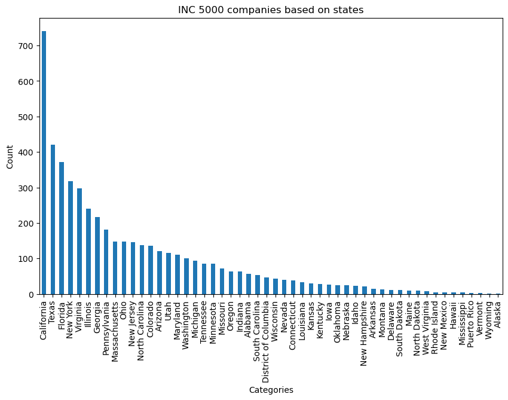

```python
data_counts = inc_5000_updated['STATE'].value_counts()

# Create a bar chart
plt.figure(figsize=(10, 6))  # Set the size of the figure
data_counts.plot(kind='bar')  # Create a bar chart
plt.xlabel('Categories')  # Label for x-axis
plt.ylabel('Count')  # Label for y-axis
plt.title('INC 5000 companies based on states')  # Title of the plot
plt.show()  # Show the plot
```

### OBSERVATION

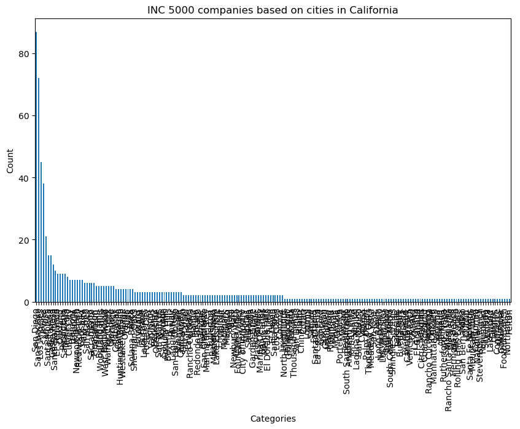

```python
#Plot a chart for all the cities located in California
#Using the filter_and_display_top_companies to get the companies
city_wise_distribution = filter_and_display_top_companies(inc_5000_updated, 'STATE', 'California', 4000)
data_counts = city_wise_distribution['CITY'].value_counts()

# Create a bar chart
plt.figure(figsize=(10, 6))  # Set the size of the figure
data_counts.plot(kind='bar')  # Create a bar chart
plt.xlabel('Categories')  # Label for x-axis
plt.ylabel('Count')  # Label for y-axis
plt.title('INC 5000 companies based on cities in California')  # Title of the plot
plt.show()  # Show the plot
```

Now further delving deeper into this data we see the cities in California along with the count of the companies in each city.  
We see that the Highest number of companies which are thriving in INC 5000 and started in california are in San Diego.

## INFERENCE

- From this we can deduce that for a person looking for job opportunities in one of these companies has a higher chances of getting a job if they relocate to California.
- We get further proof on this analysis we can also check the number of employees in each of these companies located in San Diego to better understand the prospects.
- Having more than 80 companies which are profitable it this city depicts that the growth of this city is much higher than others and can be an ideal place to settle

"I pledge on my honor that I have not given nor received any unauthorizedassistance on this assignment."  
Krupa Nilesh Shah